# Homework 1

# Exercise 1

## Problem

An Austin real-estate developer is interested in the possible economic impact of “going green” in her latest project: a new **15-story** (height) mixed-use (not all green, nor all non-green) building on **East Cesar Chavez** (location), just across I-35 from downtown. **250,000 square feet** (size) **expected baseline construction costs are $100 million** (different types of rental rate) **earning rents for 30 years or more** (possible building age)

# Question 1

I do not agree with the analysis given. If we look at the distribution of rent according to the size of the properties, we observe that the median rate may not vary that much. However, if we seperate the rent based on the type of contract, either gross contract or net contract, there will be discrepancies across median rental rate based on property size. I will classify the size of property based on four quartiles based on the collecting data.

```
##    Min. 1st Qu.  Median    Mean 3rd Qu.    Max.
##    1624   50891  128838  234638  294212 3781045
```

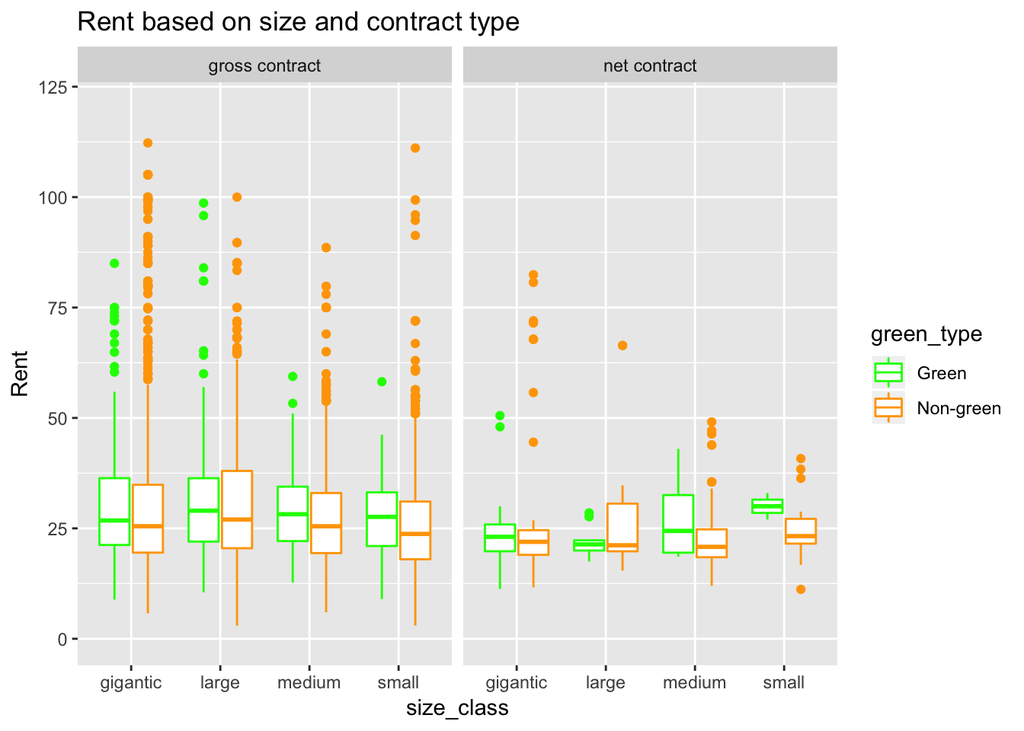

The next questionable assumption is the rent will be constant throughout the life of the building. I will look into the median rent for an interval of every 10 years

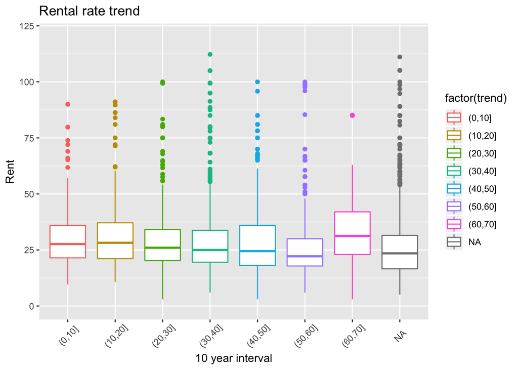

Hence, forecasting the rent to stay constant throughout building’s lifetime is irrelevant. Therefore, the revenue stream will not be constant, making the profit prediction after cost repcuperation is dubious.